# Unsupervised learning - clustering and dimension reduction

Natalie Thornton

Fall 2019

# Lab Section

Download auto data from the *Statistical Learning* book website here: http://www-bcf.usc.edu/~gareth/ISL/data.html

Today, we are going over Hierarchical clustering, K-Means Clustering, PCA, and ICA.

```r
# read in Auto data
Auto_data <- read_csv("/Users/Natalie/Desktop/sackler_fall2019/machine_learning/ML_hw1/Auto.csv")
#remove cars with unknown horsepower and set horsepower to numeric
Auto_data <- Auto_data %>%
  filter(horsepower != "?") %>%
  mutate(horsepower = as.numeric(horsepower)) %>%
  as.data.frame()

#save car names
Auto_data_names <- Auto_data$name

#data to cluster
Auto_data_clust <- Auto_data[,1:8]
dim(Auto_data_clust)
```

```
## [1] 392   8
```

```r
#392 is too much for a demo, so lets take the first 25
Auto_data_clust <- Auto_data_clust[1:25,]
rownames(Auto_data_clust) <- Auto_data_names[1:25]
```

## Hierarchical agglomerative clustering

Step 1. Assign each item to it’s own cluster. We start with 25 clusters, one for each car.

Step 2. Calculate a proximity matrix between each cluster.

Step 3. Find the pair of clusters closest to each other.

Step 4. Merge these clusters and then recalculate similarity between clusters. Some options are: single linkage (distance is calculated from the nearest neighbors), complete linkage (distance is calculated from furthest neighbor), average linkage (distance is calculated from mean of different clusters).

Step 5. Repeat Step 3 and 4 until there is only one cluster.

### In practice

Step 1. Each car is a cluster.

Step 2. Create a distance matrix from Auto_data_clust.

```r
#help("dist")
hierarchical_dist <- as.matrix(dist(Auto_data_clust, method = "euclidean"))
View(hierarchical_dist)
```

Step 3. Find the two cars that are the most similar to each other and print the names of those two cars

```r
diag(hierarchical_dist) <- NA
arrayInd(which.min(hierarchical_dist), dim(hierarchical_dist))
```

```
##      [,1] [,2]
## [1,]   23   15
```

```r
#postitions 23 and 15 are the most similar. Lets go back to the names of the cars
Auto_data_names[23]
```

```
## [1] "saab 99e"
```

```r
Auto_data_names[15]
```

```
## [1] "toyota corona mark ii"
```

Step 4. Merge the two clusters together using average linkage.

```r
#replace pos 15 with the average of pos 15 and 23
hierarchical_dist[,15] <- apply((hierarchical_dist[,c(23,15)]),1,mean)
hierarchical_dist[15,] <- apply((hierarchical_dist[c(23,15),]),2,mean)

#remove pos 23
hierarchical_dist <- hierarchical_dist[-23,-23]

#now position 15 represents the cluster containing the saab99e and the toyota corona mark ii
```

Step 5. To complete the algorithm, go back to step 3 and iterate through all of the previous steps until there are no more rows left

```r
diag(hierarchical_dist) <- NA
arrayInd(which.min(hierarchical_dist), dim(hierarchical_dist))
```

```
##      [,1] [,2]
## [1,]    4    3
```

```r
#postitions 4 and 3 are the most similar
Auto_data_names[4]
```

```
## [1] "amc rebel sst"
```

```r
Auto_data_names[3]
```

```
## [1] "plymouth satellite"
```

### R function

Now that we know how the algorithm works, let’s use the R function hclust. Plot the Dendogram resulting from clustering the Auto_data_clust using average linkage.

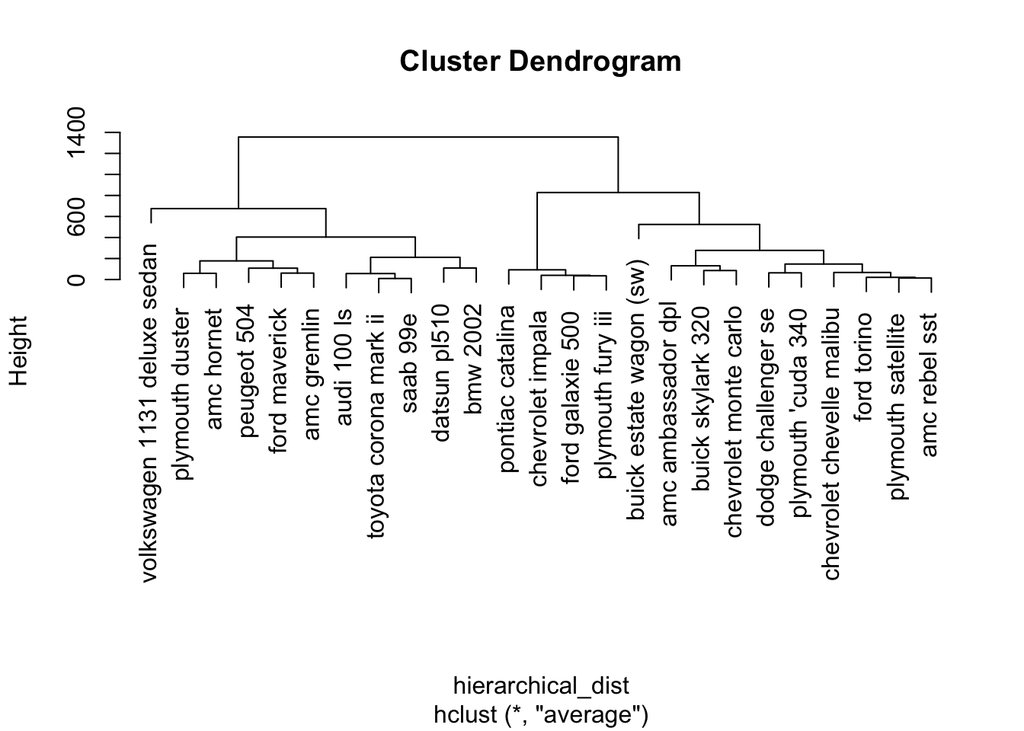

```r
hierarchical_dist <- dist(Auto_data_clust, method = "euclidean")
tree <- hclust(hierarchical_dist, method="average")
plot(tree)
```

There is one more element to hierarchical clustering: Cutting the tree. Here, we can control how many clusters we want or the height of the tree.

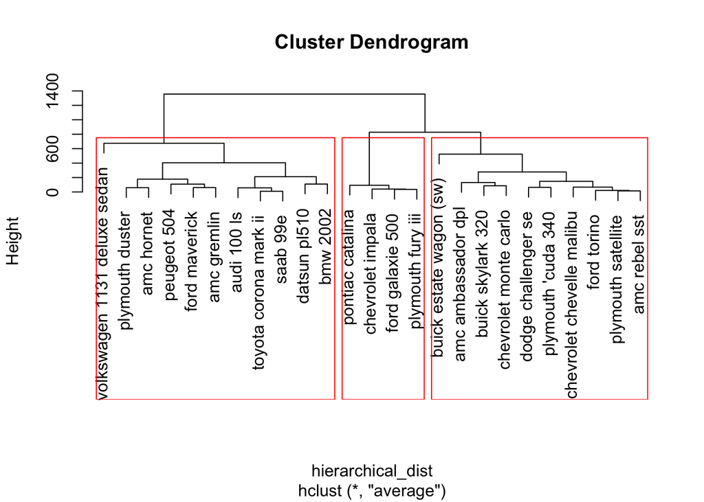

```r
#help(cutree)

# cut tree into 3 clusters
tree <- hclust(hierarchical_dist, method="average")
plot(tree)
tree_k2 <- cutree(tree, k = 2)

# plot the tree before running this line
rect.hclust(tree, k = 3, h = NULL)
```

## Principal Components Analysis (PCA)

KEEP IN MIND THAT IN PCA YOU CAN LOOK AT HOW MANY COMPENETS EXPLAIN WHAT PERCENTAGE OF THE VARIANCE; THIS ISN’T POSSIBLE WITH ICA SO YOU CAN’T NECESSARILY SEE HOW WELL YOU’VE EXPLAINED THE VARIANCE IN YOUR DATA (ICA IS GENERALLY MORE TRYING TO SPLIT SIGNALS APART??)

Principal Components Analysis is a linear dimensionality reduction algorithm. If you want to learn more about linear algebra, I suggest the MIT Open Courseware class here : https://ocw.mit.edu/courses/mathematics/18-06-linear-algebra-spring-2010/ There are two ways of doing PCA, Single Value Decomposition (SVD), and the method we will use today, using the covariance matrix of the data.

Step 1. Center data by subtracting the mean.

Step 2. Calculate covariance matrix of data.

Step 3. Perform Eigendecomposition of the covariance matrix. i.e. represent the matrix in terms of it’s eigenvalues and eigen vectors

Step 4. Multiply the eigen vectors by the original data to express the data in terms of the eigen vectors.

Step 1. Center the data by subtracting the mean of the each column from the values in that column

```r
Auto_data_clust_pca <- data.matrix(Auto_data_clust)

Center_auto <- apply(Auto_data_clust_pca, 2, function(x) x - mean(x))
```

Step 2. Calculate covariance matrix of the Auto data

```r
Covariance_auto <- cov(Center_auto)
```

Step 3. Calculate eigen values and vectors

```r
Eigen_value_auto <- eigen(Covariance_auto)$value

#columns are the eigen vectors
Eigen_vector_auto <- eigen(Covariance_auto)$vector
```

Step 4. Multiply the eigen vector matrix by the original data.

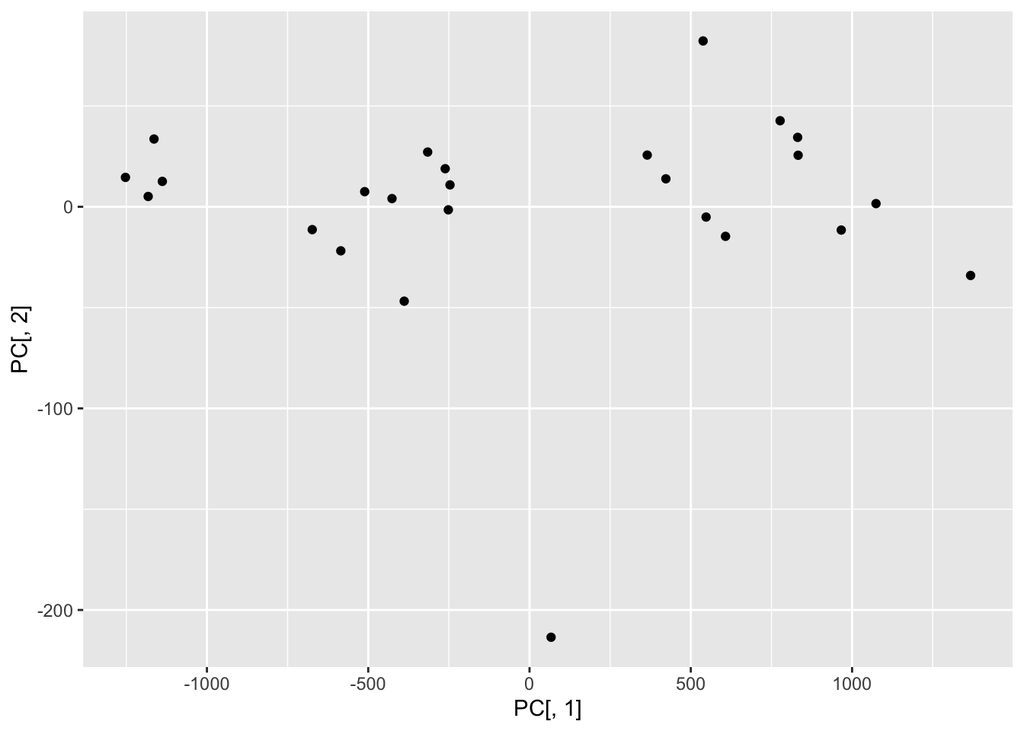

```r
PC <- as.data.frame(data.matrix(Center_auto) %*% Eigen_vector_auto)

ggplot(PC, aes(PC[,1], PC[,2])) + geom_point(aes(PC[,1], PC[,2]))
```

```r
#+ geom_text(aes(label=Auto_data_names[1:8]), nudge_x = -2.5, nudge_y = 400)
```

Step 5. Find out which principal components explain the variance in the data.

```r
#for each component, take the cumulative sum of eigen values up to that point and and divide by the total sum of eigen values
round(cumsum(Eigen_value_auto)/sum(Eigen_value_auto) * 100, digits = 2)
```

```
## [1]  99.52  99.95 100.00 100.00 100.00 100.00 100.00 100.00
```

### R function

Now that we know how PCA works, lets use the R funtion prcomp.

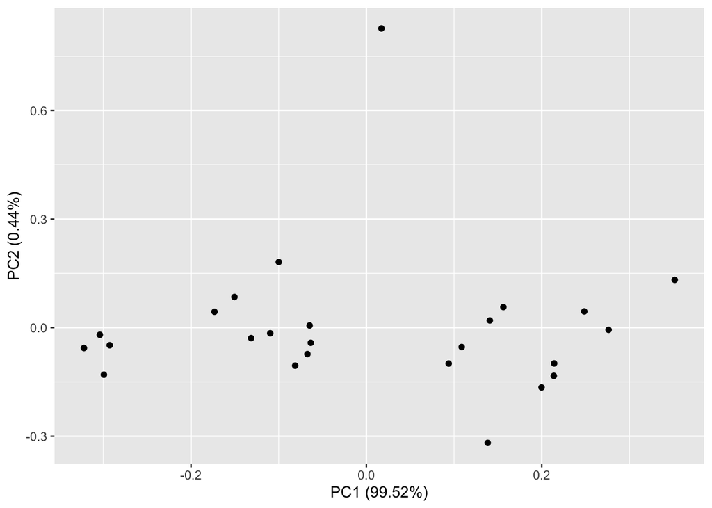

```r
help("prcomp")
autoplot(prcomp(Auto_data_clust_pca))
```

## Independent Component Analysis (ICA)

ICA is an algorithm that finds components that are independent, subcomponents of the data.

Step 1. Whiten the data by projecting the data onto the eigen vectors (PCA).

Step 2. Solve the X=AS equation by maximizing non-gaussianty in the variables(components) in S.

This results in a matrix S with components that are independent from each other.

We will use the fastICA algorithm.

First we will go backwards. Create a matrix S with the independent components

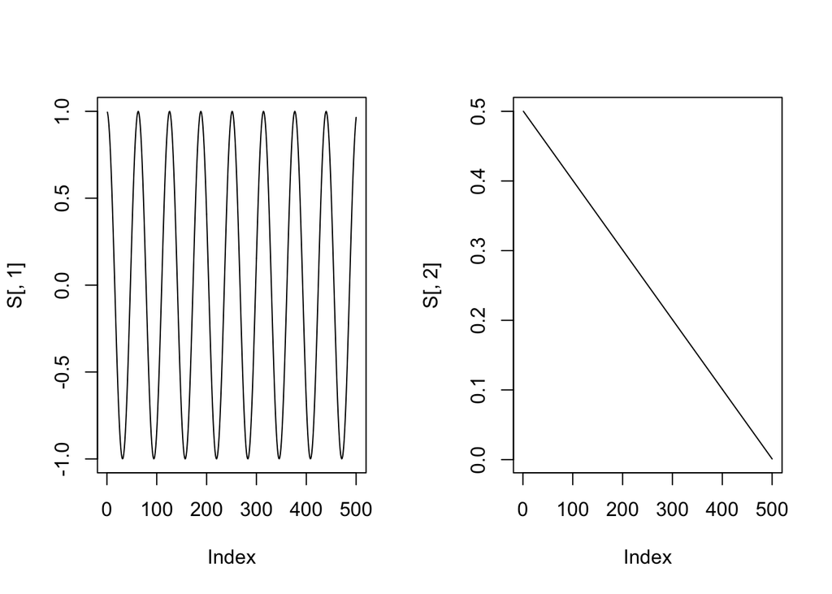

```r
#create two signals
S <- cbind(cos((1:500)/10), ((500:1)/1000))

par(mfcol = c(1, 2))
plot(S[,1], type="l")
plot(S[,2], type="l")
```

Create a mixing matrix A

```r
A <- matrix(c(0.5, 0.7, 0.423, 0.857), 2, 2)
```

Mix S using A

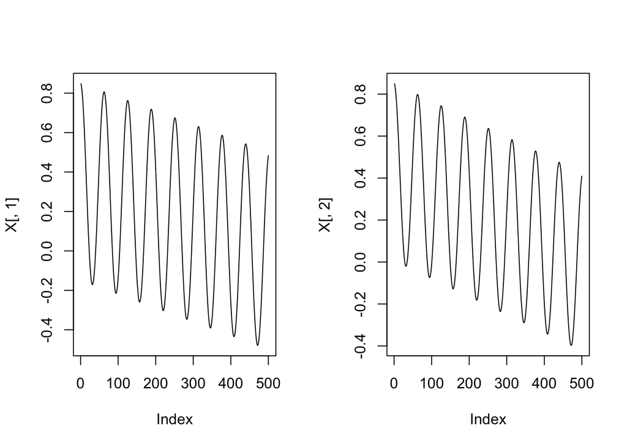

```r
X <- S %*% A
par(mfcol = c(1, 2))
plot(X[,1], type="l")
plot(X[,2], type="l")
```

Unmix using fastICA

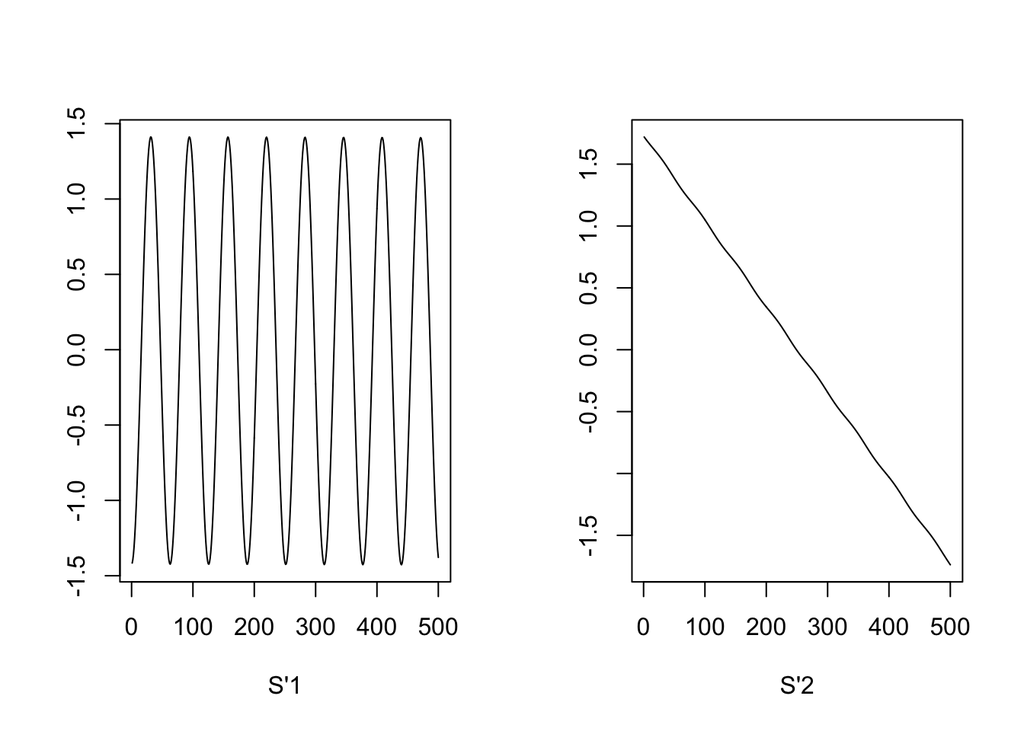

```r
par(mfcol = c(1, 2))
plot(1:500, a$S[,1], type = "l", xlab = "S'1", ylab = "")
plot(1:500, a$S[,2], type = "l", xlab = "S'2", ylab = "")
```

### ICA on the auto data

plot the independent components as a heatmap

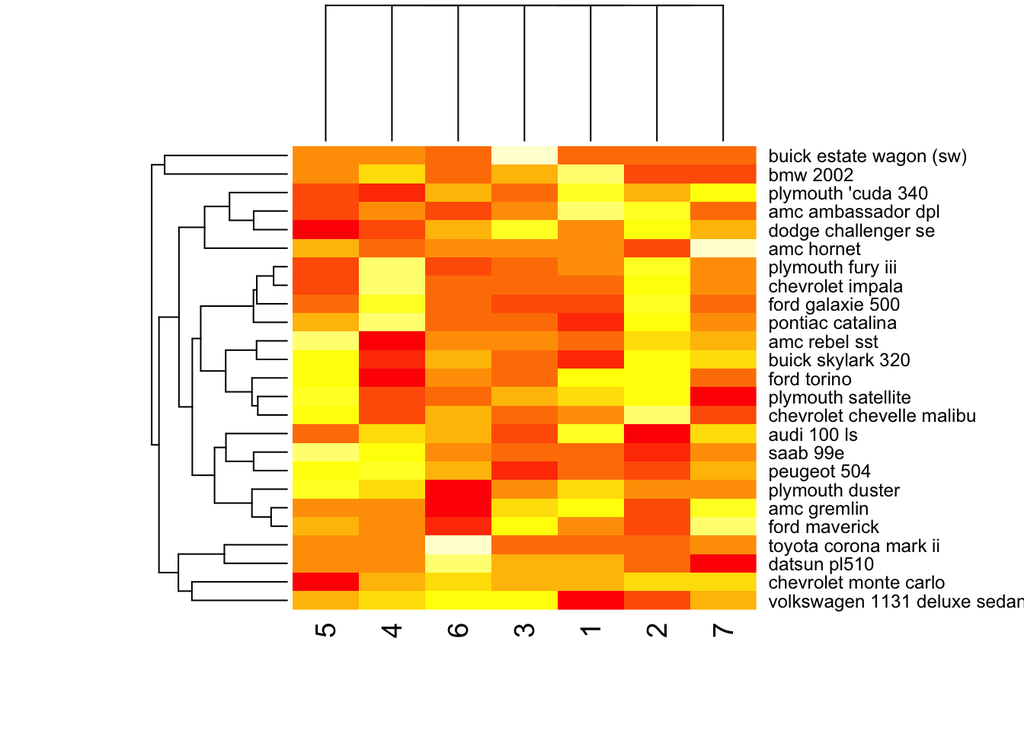

```r
heatmap(a$S)
```

## Homework

```r
data(iris)
library(randomizr)
iris
```

0. Subset the Iris dataset to only include `Sepal.Length`, `Sepal.Width`, `Petal.Length`, and `Petal.Width`.

```r
iris1 <- iris %>% select(Sepal.Length, Sepal.Width, Petal.Length, Petal.Width)
```

1. Write out the Kmeans algorithm by hand, and run two iterations of it.

Kmeans algorithm: randomly assign a number, from 1 to K, to each observation. These serve as initial cluster assignments for the observations.

```r
# randomly assign each observation to a cluster, k
k = 3
k_iris <- iris1 %>% mutate(cluster = simple_ra(150, num_arms = k, conditions = c(1:k)))
head(k_iris)
```

|  | Sepal.Length | Sepal.Width | Petal.Length | Petal.Width | cluster |
| --- | --- | --- | --- | --- | --- |
| 1 | 5.1 | 3.5 | 1.4 | 0.2 | 3 |
| 2 | 4.9 | 3.0 | 1.4 | 0.2 | 3 |
| 3 | 4.7 | 3.2 | 1.3 | 0.2 | 3 |
| 4 | 4.6 | 3.1 | 1.5 | 0.2 | 2 |
| 5 | 5.0 | 3.6 | 1.4 | 0.2 | 1 |
| 6 | 5.4 | 3.9 | 1.7 | 0.4 | 2 |

```r
# compute the cluster centroid of each cluster, k
clusters <- k_iris %>%
  group_by(cluster) %>%
  summarize(sepal_len_mean = mean(Sepal.Length), sepal_width_mean = mean(Sepal.Width),
            petal_len_mean = mean(Petal.Length), petal_width_mean = mean(Petal.Width))

clusters
```

| cluster | sepal_len_mean | sepal_width_mean | petal_len_mean | petal_width_mean |
| --- | --- | --- | --- | --- |
| 1 | 5.841667 | 3.058333 | 3.860417 | 1.227083 |
| 2 | 5.914286 | 3.058929 | 3.850000 | 1.225000 |
| 3 | 5.758696 | 3.054348 | 3.539130 | 1.139130 |

Assign each observation to the cluster whose centroid is closest (defined with euclidian distance):

```r
# check distance from each observation to the centroid of each cluster:

# build a new df to hold the distances to clusters for each observation
cluster_dist = k_iris[,FALSE]

for (i in 1:k) {
  # set up columns for each cluster k in distance df
  colname <- paste("dist", i , sep="_")
  cluster_dist[, colname] <- NA

  # calculate the distance from each observation to each cluster, k
  cluster_dist <- cluster_dist %>% mutate(!!colname := (
    (clusters$sepal_len_mean[i] - k_iris$Sepal.Length)**2 +
      (clusters$sepal_width_mean[i] - k_iris$Sepal.Width)**2 +
      (clusters$petal_len_mean[i] - k_iris$Petal.Length)**2 +
      (clusters$petal_width_mean[i] - k_iris$Petal.Width)**2
    ))
}

head(cluster_dist)
```

|  | dist_1 | dist_2 | dist_3 |
| --- | --- | --- | --- |
| 1 | 7.853689 | 7.910730 | 6.090331 |
| 2 | 7.998689 | 8.085373 | 6.198157 |
| 3 | 8.934106 | 9.047516 | 7.037722 |
| 4 | 8.169939 | 8.302159 | 6.384679 |
| 5 | 8.110356 | 8.181802 | 6.331200 |
| 6 | 6.254939 | 6.275016 | 4.772505 |

```r
# select shortest distance from observation to cluster and assign observation to that cluster
for (i in 1:nrow(cluster_dist)) {
  x <- which.min(as.numeric(cluster_dist[i,]))
  k_iris[i,'cluster'] = x
}

# look at new cluster assignments
k_iris %>% arrange(cluster)
```

| Sepal.Length | Sepal.Width | Petal.Length | Petal.Width | cluster |
| --- | --- | --- | --- | --- |
| 5.5 | 2.3 | 4.0 | 1.3 | 1 |
| 5.7 | 2.8 | 4.5 | 1.3 | 1 |
| 5.2 | 2.7 | 3.9 | 1.4 | 1 |
| 5.9 | 3.0 | 4.2 | 1.5 | 1 |
| 5.6 | 3.0 | 4.5 | 1.5 | 1 |
| 5.8 | 2.7 | 4.1 | 1.0 | 1 |
| 5.6 | 2.5 | 3.9 | 1.1 | 1 |
| 5.9 | 3.2 | 4.8 | 1.8 | 1 |
| 5.8 | 2.7 | 3.9 | 1.2 | 1 |
| 6.0 | 2.7 | 5.1 | 1.6 | 1 |

[output cut: 140 more lines]

```r
# second iteration of kmeans clustering as above:

# compute new cluster centroids for each cluster, k
clusters <- k_iris %>%
  group_by(cluster) %>%
  summarize(sepal_len_mean = mean(Sepal.Length), sepal_width_mean = mean(Sepal.Width),
            petal_len_mean = mean(Petal.Length), petal_width_mean = mean(Petal.Width))


for (i in 1:k) {
  colname <- paste("dist", i , sep="_")
  cluster_dist[, colname] <- NA

  # calculate the distance from each observation to each cluster, k
  cluster_dist <- cluster_dist %>% mutate(!!colname := (
    (clusters$sepal_len_mean[i] - k_iris$Sepal.Length)**2 +
      (clusters$sepal_width_mean[i] - k_iris$Sepal.Width)**2 +
      (clusters$petal_len_mean[i] - k_iris$Petal.Length)**2 +
      (clusters$petal_width_mean[i] - k_iris$Petal.Width)**2
    ))
}

# select shortest distance from observation to cluster and assign observation to that cluster
for (i in 1:nrow(cluster_dist)) {
  x <- which.min(as.numeric(cluster_dist[i,]))
  k_iris[i,'cluster'] = x
}

# look at new cluster assignments
head(k_iris %>% arrange(cluster))
```

|  | Sepal.Length | Sepal.Width | Petal.Length | Petal.Width | cluster |
| --- | --- | --- | --- | --- | --- |
| 1 | 6.4 | 3.2 | 4.5 | 1.5 | 1 |
| 2 | 5.5 | 2.3 | 4.0 | 1.3 | 1 |
| 3 | 5.7 | 2.8 | 4.5 | 1.3 | 1 |
| 4 | 4.9 | 2.4 | 3.3 | 1.0 | 1 |
| 5 | 5.2 | 2.7 | 3.9 | 1.4 | 1 |
| 6 | 5.0 | 2.0 | 3.5 | 1.0 | 1 |

2. Run PCA on the Iris dataset. Plot a scatter plot of PC1 vs PC2 and include the percent variance those PCs describe.

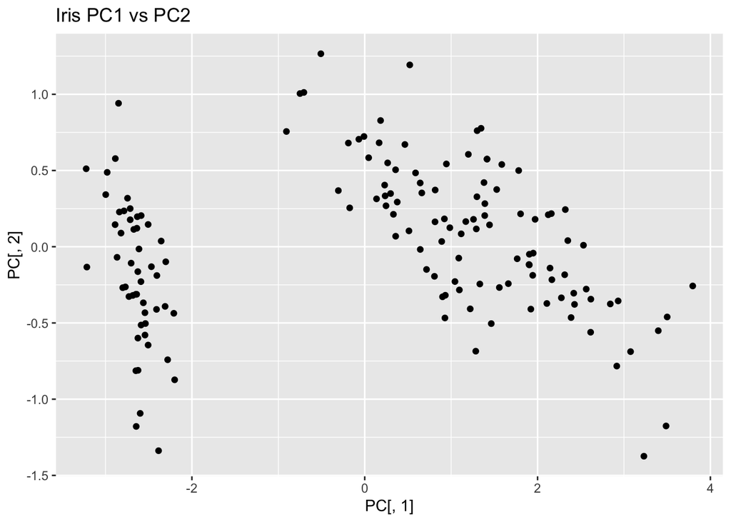

```r
# ran through step-by-step here:

# Step 1.Center the data by subtracting the mean of the each column from the values in that column
center_iris <- data.matrix(iris1) %>% apply(2, function(x) x - mean(x))

# Step 2. Calculate covariance matrix of the data
covariance_iris <- cov(center_iris)

#Step 3.Calculate eigen values and vectors
eigen_value_iris <- eigen(covariance_iris)$value

#columns are the eigen vectors
eigen_vector_iris <- eigen(covariance_iris)$vector

#Step 4.Multiply the eigen vector matrix by the original data.
PC <- as.data.frame(data.matrix(center_iris) %*% eigen_vector_iris)

ggplot(PC, aes(PC[,1], PC[,2])) + geom_point(aes(PC[,1], PC[,2])) +
  ggtitle("Iris PC1 vs PC2")
```

```r
# explaining proportion of variance:
pca <- prcomp(iris1, scale = TRUE)
summary(pca)
```

```
## Importance of components:
##                           PC1    PC2     PC3     PC4
## Standard deviation     1.7084 0.9560 0.38309 0.14393
## Proportion of Variance 0.7296 0.2285 0.03669 0.00518
## Cumulative Proportion  0.7296 0.9581 0.99482 1.00000
```

**The first two PCs together explain 95.81% of variance**

3. Run ICA on the Iris dataset. Plot the independent components as a heatmap.

```r
a <- fastICA(iris1, 3, alg.typ = "parallel", fun = "logcosh", alpha = 1,
             method = "R", row.norm = FALSE, maxit = 200,
             tol = 0.0001, verbose = TRUE)
```

[output not shown]

[output not shown]

[output not shown]

[output not shown]

[output not shown]

[output not shown]

[output not shown]

[output not shown]

[output not shown]

[output not shown]

[output not shown]

[output not shown]

[output not shown]

[output not shown]

[output not shown]

[output not shown]

[output not shown]

[output not shown]

[output not shown]

[output not shown]

[output not shown]

[output not shown]

[output not shown]

[output not shown]

[output not shown]

[output not shown]

[output not shown]

[output not shown]

[output not shown]

[output not shown]

[output not shown]

[output not shown]

[output not shown]

[output not shown]

[output not shown]

[output not shown]

[output not shown]

[output not shown]

[output not shown]

[output not shown]

[output not shown]

[output not shown]

[output not shown]

[output not shown]

[output not shown]

[output not shown]

[output not shown]

[output not shown]

[output not shown]

[output not shown]

[output not shown]

[output not shown]

[output not shown]

[output not shown]

[output not shown]

[output not shown]

[output not shown]

[output not shown]

[output not shown]

[output not shown]

[output not shown]

[output not shown]

[output not shown]

[output not shown]

[output not shown]

[output not shown]

[output not shown]

[output not shown]

[output not shown]

[output not shown]

[output not shown]

[output not shown]

[output not shown]

[output not shown]

[output not shown]

[output not shown]

[output not shown]

[output not shown]

[output not shown]

[output not shown]

[output not shown]

[output not shown]

[output not shown]

[output not shown]

[output not shown]

[output not shown]

[output not shown]

[output not shown]

[output not shown]

[output not shown]

[output not shown]

[output not shown]

[output not shown]

[output not shown]

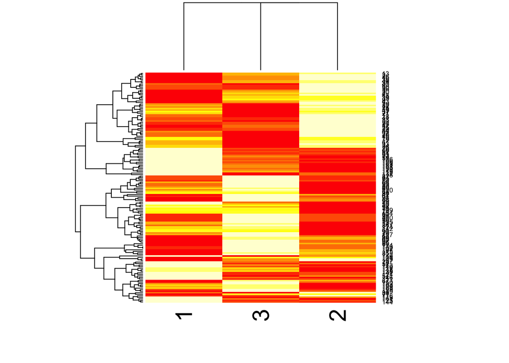

```r
heatmap(a$S)
```

4. Use Kmeans to cluster the Iris data.

```r
library(cluster)
```

- Use the silhouette function in the cluster package to find the optimal number of clusters for kmeans for the iris dataset. Then cluster using kmeans clustering. Does the data cluster by species?

**The data does not cluster by species– there are three different species and the data is optimally split into two clusters.**

- Using this clustering, color the PCA plot according to the clusters.

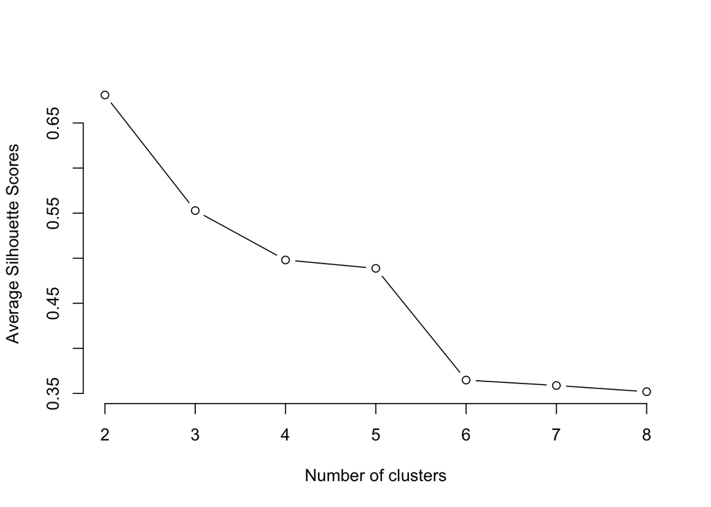

```r
# function generates the silhouette widths for any number of clusters, k:
silhouette_func <- function(k){
  # first runs kmeans for k number of clusters
  k_cluster <- kmeans(iris1, centers = k, nstart=25)
  # then checks the silhouette widths for k clusters
  sil <- silhouette(k_cluster$cluster, dist(iris1))
  # averages those silhouette widths so we can generate a useful comparative plot
  mean(sil[, 3])
}

# checking on silhouette widths for between 2 and 8 clusters:
k <- 2:8
avg_sil <- sapply(k, silhouette_func)  # apply the function above

# plot the average silhouette widths to select the optimum number of clusters
# peak of plot will be optimal k
plot(k, type='b', avg_sil, xlab='Number of clusters', ylab='Average Silhouette Scores', frame=FALSE)
```

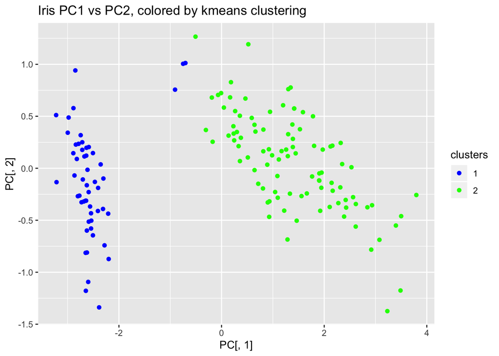

```r
# optimal k = 2, so run kmeans with k = 2
k_cluster <- kmeans(iris1, centers = 2, nstart=25)

# colored PCA plot
ggplot(PC, aes(PC[,1], PC[,2], color = as.factor(k_cluster$cluster))) +
  geom_point(aes(PC[,1], PC[,2])) +
  ggtitle("Iris PC1 vs PC2, colored by kmeans clustering") +
  labs(col = "clusters") +
  scale_colour_manual(values = c("Blue", "Green"))
```

5. Use hierarchical clustering to cluster the Iris data.
- Try two different linkage types, and two different distance metrics.
- For one linkage type and one distance metric, try two different cut points.
- Using this clustering, color the PCA plot according to the clusters. (6 plots in total)

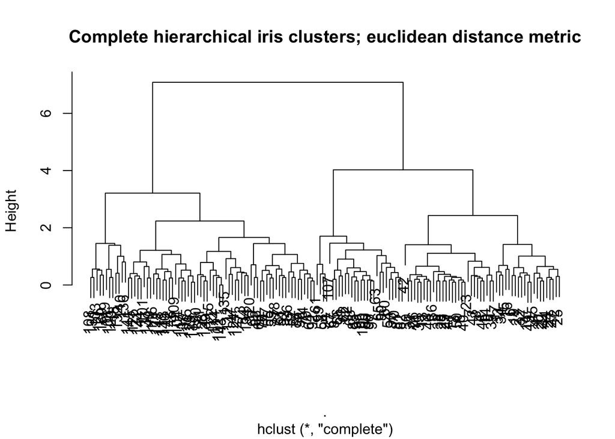

```r
# Linkage: complete; Distance metric: euclidean
tree <- dist(iris1, method = "euclidean") %>%
  hclust(method="complete")
plot(tree, main = "Complete hierarchical iris clusters; euclidean distance metric")
```

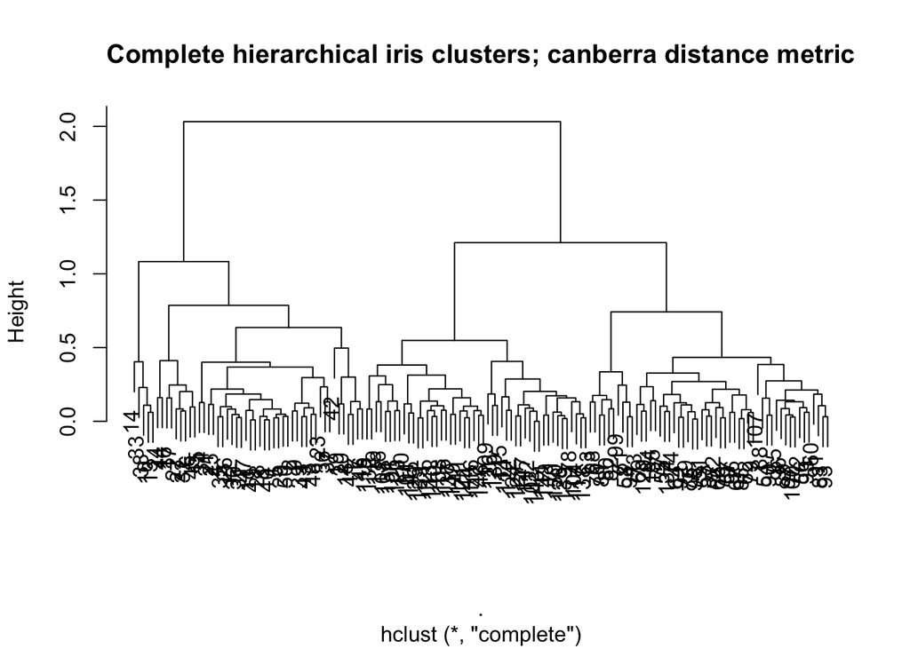

```r
# Linkage: complete; Distance metric: canberra
tree <- dist(iris1, method = "canberra") %>%
  hclust(method="complete")
plot(tree, main = "Complete hierarchical iris clusters; canberra distance metric")
```

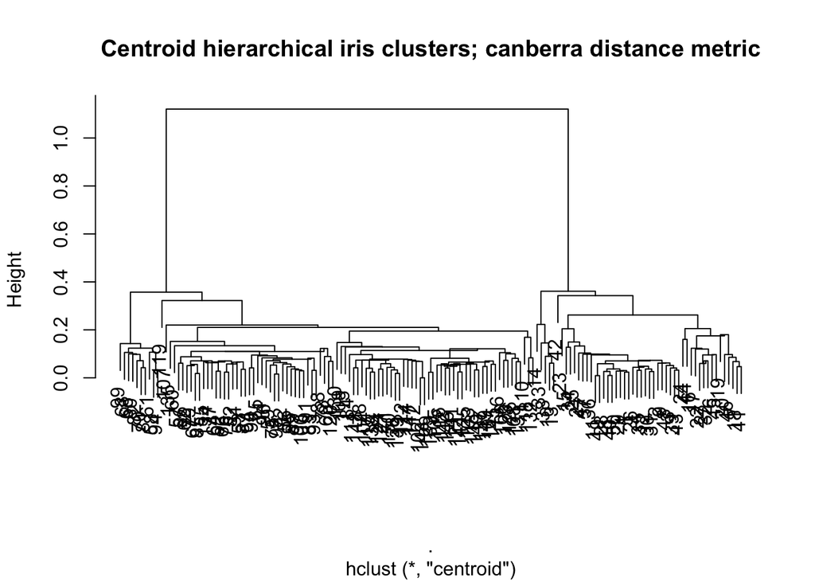

```r
# Linkage: centroid; Distance metric: canberra
tree <- dist(iris1, method = "canberra") %>%
  hclust(method="centroid")
plot(tree, main = "Centroid hierarchical iris clusters; canberra distance metric")
```

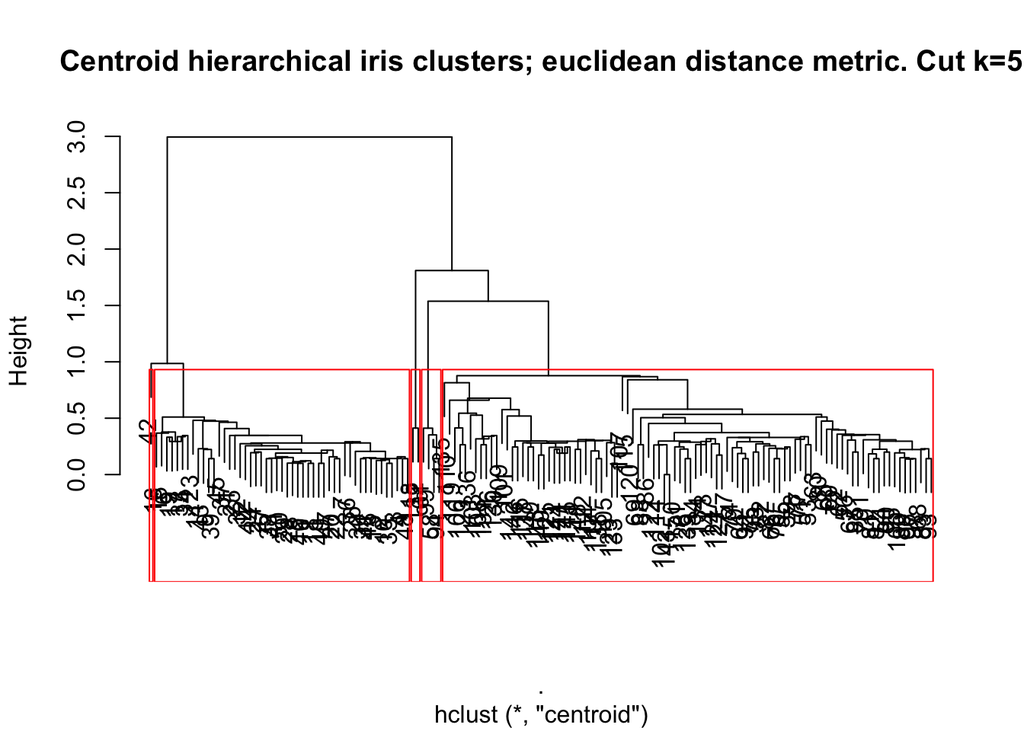

```r
# Linkage: centroid; Distance metric: euclidean
tree <- dist(iris1, method = "euclidean") %>%
  hclust(method="centroid")
plot(tree, main = "Centroid hierarchical iris clusters; euclidean distance metric. Cut k=5")

# Looking at cut points in Centroid clusters with euclidean distance:
rect.hclust(tree, k = 5, h = NULL)
```

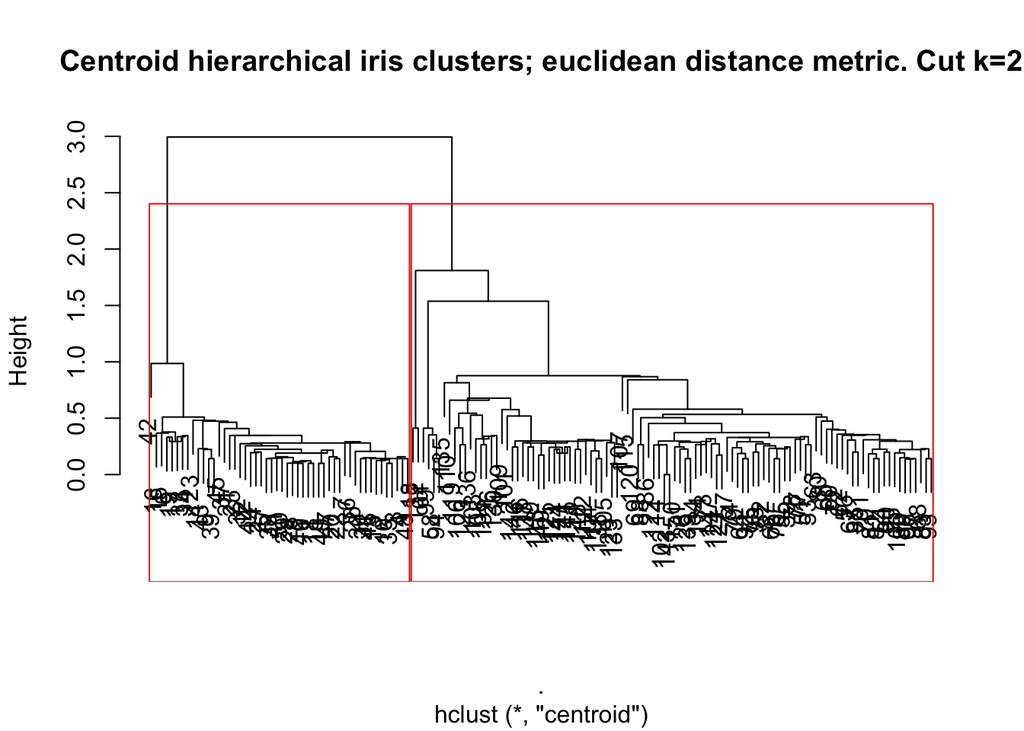

```r
plot(tree, main = "Centroid hierarchical iris clusters; euclidean distance metric. Cut k=2")
rect.hclust(tree, k = 2, h = NULL)
```

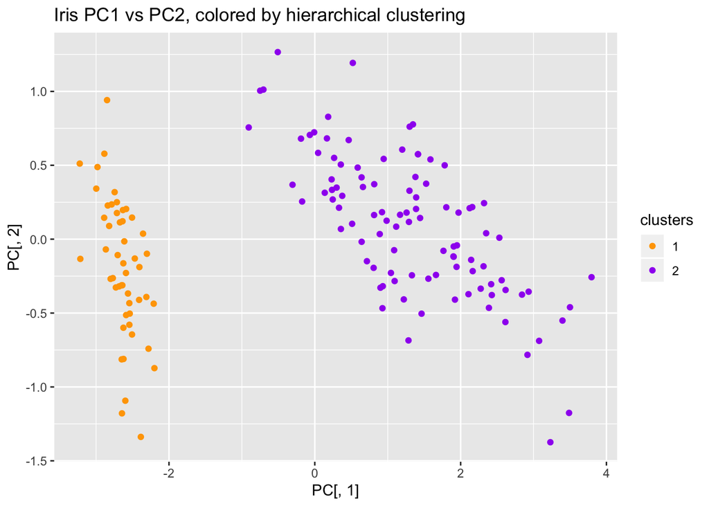

```r
# make list for coloring PCA plot:
tree_k2 <- cutree(tree, k = 2)

# colored PCA plot
ggplot(PC, aes(PC[,1], PC[,2], color = as.factor(tree_k2))) +
  geom_point(aes(PC[,1], PC[,2])) +
  ggtitle("Iris PC1 vs PC2, colored by hierarchical clustering") +
  labs(col = "clusters") +
  scale_colour_manual(values = c("Orange", "Purple"))
```

# Optional material

On PCA:

Eigen Vectors and Eigen Values http://www.visiondummy.com/2014/03/eigenvalues-eigenvectors/ Linear Algebra by Prof. Gilbert Strang https://ocw.mit.edu/courses/mathematics/18-06-linear-algebra-spring-2010/video-lectures/ http://www.cs.otago.ac.nz/cosc453/student_tutorials/principal_components.pdf https://stats.stackexchange.com/questions/2691/making-sense-of-principal-component-analysis-eigenvectors-eigenvalues

On ICA:

Independent Component Analysis: Algorithms and Applications https://www.cs.helsinki.fi/u/ahyvarin/papers/NN00new.pdf Tutorial on ICA taken from http://rstudio-pubs-static.s3.amazonaws.com/93614_be30df613b2a4707b3e5a1a62f631d19.html